# Lily Campbell Portfolio of Projects

# CNN vs. ViT for Car Brand Image Classification

Lily Campbell

Autumn 2024

# Project Definition:

Goal: Classify images of cars by brand, and determine whether a CNN or ViT model performs better on this task

Applications:

- Applies to problems in law enforcement - Many scenarios when license plates are not visible or not readable to a camera, but information around car type would be useful
- Finding lost cars: Could be helpful for drones to identify missing or stolen parked cars

## Key Literature

Comparison of CNN vs transformer model for image recognition

- An image is worth 16x16 words: https://arxiv.org/pdf/2010.11929

  The paper on Vision Transformer (ViT) implements a pure transformer model, without the need for convolutional blocks, on image sequences to classify images. The paper showcases how a ViT can attain better results than most state-of-the-art CNN networks on various image recognition datasets while using considerably lesser computational resources.

  They apply a transformer directly to images, with the fewest possible modifications. To do so, they split an image into patches and provide the sequence of linear embeddings of these patches as an input to a Transformer. Image patches are treated the same way as tokens (words) in an NLP application. They train the model on image classification in supervised fashion.
- A convnet for the 2020s: https://arxiv.org/pdf/2201.03545

  Surprisingly, ConvNeXts, constructed entirely from standard ConvNet modules, compete favorably with Transformers in terms of accuracy, scalability and robustness across all major benchmarks.

```python
import pandas as pd
import numpy as np
import matplotlib.pyplot as plt
import os
from sklearn.model_selection import train_test_split
from sklearn.metrics import confusion_matrix, classification_report
from sklearn.preprocessing import LabelEncoder

from PIL import Image
import cv2


#Utilize tensorflow for initial model exploration
from tensorflow.keras.preprocessing import image
import tensorflow as tf
import tensorflow_datasets as tfds

import keras
from keras import models, layers
from tensorflow.keras.models import Sequential
from tensorflow.keras.layers import Conv2D, MaxPooling2D, Flatten, Dense, Dropout, BatchNormalization
from tensorflow.keras.optimizers import Adam
from tensorflow.keras.utils import to_categorical
```

```python
# Load the Drive helper and mount
from google.colab import drive

# This will prompt for authorization.
drive.mount('/content/drive')
```

# Modeling Approach

I perform a comparison of a regular CNN, a CNN with transfer learning, a ViT model, and a ViT model with transfer learning. This will allow me to analyze the performance of each model type on the task of car brand identification, as well as select a final model based on performance.

I tested different architectures and hyperparameters including optimizer, loss function, and learning rate to maximize performance on unseen data.

A minimum size of 4 KB per image preserved dataset size, and excludes images without a car image or brand emblem in them

# Initial CNN - no transfer learning for base comparison

```python
brand = ['Acura', 'Ford', 'Jeep', 'Porche', 'BMW', 'Toyota', 'Tesla', 'Audi']
num_images_scraped = [1000, 1000, 1000, 956, 810, 1000, 743, 642 ]

X = []
y = []
#Need minimum size of file to sort out bad ones taken in by the scrape
min_size = 4000
brand_ct = []
j=0
for brand_name in brand:
    bra = brand_name
    print(brand_name)
    brand_counter = 0
    for i in range(1,num_images_scraped[j]):
        #img_src = f'drive/MyDrive/Machine_Learning/{bra}_Images/{i}.jpg'
        img_src = f'drive/MyDrive/UChicago/{bra}_Images/{i}.jpg'
        file_size = os.path.getsize(img_src)
        if min_size <= file_size:
          src = cv2.imread(img_src, cv2.IMREAD_COLOR)
          #dst = cv2.cvtColor(src, cv2.COLOR_BGR2GRAY)
        #  X.append(cv2.resize(dst, dsize=(200, 300), interpolation=cv2.INTER_AREA))
          X.append(cv2.resize(src, dsize=(200, 300), interpolation=cv2.INTER_AREA))
          y.append(bra)
          brand_counter = brand_counter + 1
    brand_ct.append(brand_counter)
    j=j+1
```

```
Acura
Ford
Jeep
Porche
BMW
Toyota
Tesla
Audi
```

```python
len(X)
```

```
5118
```

```python
# Initialize an empty list for resized images
X_resized_list = []

for img in X:
    # Ensure the image has 3 channels (convert grayscale to RGB if needed)
    if len(img.shape) == 2:  # Grayscale image
        img = tf.image.grayscale_to_rgb(tf.expand_dims(img, axis=-1))
    elif img.shape[-1] != 3:
        raise ValueError("Image does not have 3 channels (RGB).")

    # Resize the image to 299x299
    resized_img = tf.image.resize(img, (299, 299)).numpy()
    X_resized_list.append(resized_img)
```

```python
# Convert list to a numpy array
X_resized = np.array(X_resized_list)

# Normalize images to the range [0, 1]
X_resized = X_resized / 255.0

print(f"Shape of X_resized: {X_resized.shape}")
```

```
Shape of X_resized: (5118, 299, 299, 3)
```

```python
brand_ct
```

```
[676, 721, 668, 769, 584, 726, 507, 467]
```

```python
# Encode string labels into integers
label_encoder = LabelEncoder()
y_encoded = label_encoder.fit_transform(y)

# Convert integer labels to one-hot encoding
num_classes = len(np.unique(y_encoded))
y_one_hot = to_categorical(y_encoded, num_classes)
```

```python
#Test train split, and leave out extra to be unseen test data
X_train, X_test1, y_train, y_test1 = train_test_split(X_resized, y_one_hot, test_size=0.3, stratify=y_one_hot)
```

```python
X_val, X_test, y_val, y_test = train_test_split(X_test1, y_test1, test_size=0.30, stratify=y_test1)
```

[figure not shown]

```python
X_train = np.array(X_train)
y_train = np.array(y_train)
X_test = np.array(X_test)
y_test = np.array(y_test)
X_val= np.array(X_val)
y_val = np.array(y_val)

#Show sample images
fig, axes = plt.subplots(1,10,figsize=(25,10))
for i in range(0,10):
    axes[i].imshow(X_train[i])
```

```python
X_train.shape, X_val.shape, X_test.shape, y_train.shape, y_val.shape, y_test.shape
```

```
((3582, 299, 299, 3),
 (1075, 299, 299, 3),
 (461, 299, 299, 3),
 (3582, 8),
 (1075, 8),
 (461, 8))
```

```python
# Simple CNN model on car brands

Number_brands =8
model = Sequential([
    #Conv2D(32, (5, 5), activation='relu', input_shape=(300, 200,1) ,padding='same' ),
    Conv2D(32, (5, 5), activation='relu', input_shape=(299, 299,3) ,padding='same' ),
    MaxPooling2D((2, 2)),
   # BatchNormalization(),
    #Dropout(0.8),

    Conv2D(64, (5, 5), activation='relu' ,padding='same'),
    MaxPooling2D((2, 2)),
   # BatchNormalization(),
   # Dropout(0.3),

    Conv2D(64, (5, 5), activation='relu',padding='same'),
    MaxPooling2D((2, 2)),

    Conv2D(64, (5, 5), activation='relu',padding='same'),
    MaxPooling2D((2, 2)),
    Dropout(0.2),

    Conv2D(64, (5, 5), activation='relu',padding='same'),
    MaxPooling2D((2, 2)),

    Conv2D(64, (5, 5), activation='relu',padding='same'),
    MaxPooling2D((2, 2)),


    Conv2D(64, (5, 5), activation='relu',padding='same'),
    MaxPooling2D((2, 2)),

    Flatten(),
    #Dense(64, activation='relu'),
    Dense(64, activation='relu'),
    #BatchNormalization(),
    Dropout(0.2),
    Dense(Number_brands, activation='softmax')
])
```

I tried many different architectures, batch normalization, and different dropout rates to mitigate overfitting. The architecture displayed above had the best validation performance achieved.

```python
model.compile(optimizer=Adam(learning_rate=0.00003), loss='categorical_crossentropy', metrics=['accuracy']) #accuracy 36% .004
#model.compile(optimizer=Adam(learning_rate=0.0009), loss='categorical_crossentropy', metrics=['accuracy'])
```

```python
history = model.fit(X_train, y_train, epochs=15, batch_size=64,
                    validation_data=(X_val, y_val))
```

```
56/56 ━━━━━━━━━━━━━━━━━━━━ 15s 267ms/step - accuracy: 0.1582 - loss: 2.0649 - val_accuracy: 0.1647 - val_loss: 2.0658
56/56 ━━━━━━━━━━━━━━━━━━━━ 13s 226ms/step - accuracy: 0.1391 - loss: 2.0652 - val_accuracy: 0.1786 - val_loss: 2.0612
56/56 ━━━━━━━━━━━━━━━━━━━━ 13s 229ms/step - accuracy: 0.1664 - loss: 2.0557 - val_accuracy: 0.1870 - val_loss: 2.0522
56/56 ━━━━━━━━━━━━━━━━━━━━ 13s 229ms/step - accuracy: 0.1731 - loss: 2.0528 - val_accuracy: 0.1860 - val_loss: 2.0442
56/56 ━━━━━━━━━━━━━━━━━━━━ 13s 230ms/step - accuracy: 0.1917 - loss: 2.0438 - val_accuracy: 0.1991 - val_loss: 2.0404
56/56 ━━━━━━━━━━━━━━━━━━━━ 13s 230ms/step - accuracy: 0.1826 - loss: 2.0365 - val_accuracy: 0.1944 - val_loss: 2.0305
56/56 ━━━━━━━━━━━━━━━━━━━━ 13s 234ms/step - accuracy: 0.2021 - loss: 2.0215 - val_accuracy: 0.1972 - val_loss: 2.0246
56/56 ━━━━━━━━━━━━━━━━━━━━ 13s 231ms/step - accuracy: 0.2028 - loss: 2.0226 - val_accuracy: 0.1926 - val_loss: 2.0258
56/56 ━━━━━━━━━━━━━━━━━━━━ 13s 231ms/step - accuracy: 0.2074 - loss: 2.0091 - val_accuracy: 0.2028 - val_loss: 2.0085
56/56 ━━━━━━━━━━━━━━━━━━━━ 13s 232ms/step - accuracy: 0.2100 - loss: 1.9908 - val_accuracy: 0.2102 - val_loss: 1.9988
56/56 ━━━━━━━━━━━━━━━━━━━━ 13s 232ms/step - accuracy: 0.2289 - loss: 1.9757 - val_accuracy: 0.2177 - val_loss: 1.9901
56/56 ━━━━━━━━━━━━━━━━━━━━ 13s 232ms/step - accuracy: 0.2406 - loss: 1.9581 - val_accuracy: 0.2298 - val_loss: 1.9809
56/56 ━━━━━━━━━━━━━━━━━━━━ 13s 232ms/step - accuracy: 0.2481 - loss: 1.9540 - val_accuracy: 0.2456 - val_loss: 1.9656
56/56 ━━━━━━━━━━━━━━━━━━━━ 13s 232ms/step - accuracy: 0.2742 - loss: 1.9235 - val_accuracy: 0.2391 - val_loss: 1.9677
56/56 ━━━━━━━━━━━━━━━━━━━━ 13s 233ms/step - accuracy: 0.2587 - loss: 1.9412 - val_accuracy: 0.2344 - val_loss: 1.9575
```

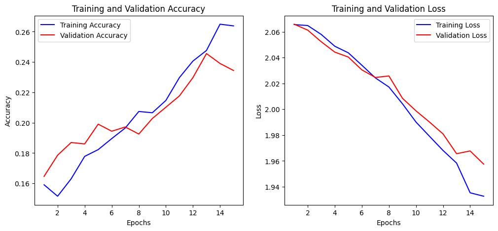

```python
epochs = range(1, len(history.history['accuracy']) + 1)
plt.figure(figsize=(12, 5))

# Accuracy plot
plt.subplot(1, 2, 1)
plt.plot(epochs, history.history['accuracy'], 'b', label='Training Accuracy')
plt.plot(epochs, history.history['val_accuracy'], 'r', label='Validation Accuracy')
plt.title('Training and Validation Accuracy')
plt.xlabel('Epochs')
plt.ylabel('Accuracy')
plt.legend()

# Loss plot
plt.subplot(1, 2, 2)
plt.plot(epochs, history.history['loss'], 'b', label='Training Loss')
plt.plot(epochs, history.history['val_loss'], 'r', label='Validation Loss')
plt.title('Training and Validation Loss')
plt.xlabel('Epochs')
plt.ylabel('Loss')
plt.legend()

plt.show()
```

With greater than 15 epochs the model started to decrease in accuracy, and overfitting greatly increased, so I limit the training to 15 epochs.

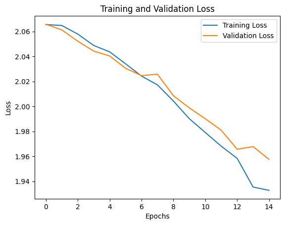

```python
plt.plot(history.history['loss'], label='Training Loss')
plt.plot(history.history['val_loss'], label='Validation Loss')
plt.title('Training and Validation Loss')
plt.xlabel('Epochs')
plt.ylabel('Loss')
plt.legend()
plt.show()
```

```
34/34 ━━━━━━━━━━━━━━━━━━━━ 1s 26ms/step
Classification Report Validation:
               precision    recall  f1-score   support

       Acura       0.31      0.19      0.23       142
        Audi       0.21      0.14      0.17        98
         BMW       0.19      0.07      0.10       122
        Ford       0.21      0.28      0.24       151
        Jeep       0.24      0.67      0.35       141
      Porche       0.30      0.28      0.29       162
       Tesla       0.14      0.01      0.02       106
      Toyota       0.16      0.13      0.14       153

    accuracy                           0.23      1075
   macro avg       0.22      0.22      0.19      1075
weighted avg       0.22      0.23      0.20      1075
```

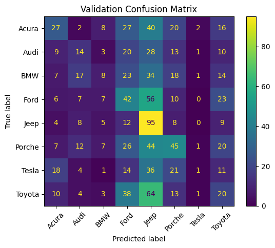

```python
from sklearn.metrics import confusion_matrix, ConfusionMatrixDisplay

# Predict on validation data
y_pred = model.predict(X_val)
# Convert predictions and true labels from one-hot to label indices
y_pred_classes = np.argmax(y_pred, axis=1)
y_true_classes = np.argmax(y_val, axis=1)
y_true = np.argmax(y_val, axis=1)
# Get class labels from the encoder
class_labels = label_encoder.classes_

# Generate classification report
class_report = classification_report(y_true, y_pred_classes, target_names=class_labels)
print("Classification Report Validation:\n", class_report)

# Create confusion matrix
cm = confusion_matrix(y_true_classes, y_pred_classes)

# Display confusion matrix
disp = ConfusionMatrixDisplay(confusion_matrix=cm, display_labels=class_labels)
disp.plot(cmap='viridis', xticks_rotation=45)

plt.title('Validation Confusion Matrix')
plt.show()
```

```
15/15 ━━━━━━━━━━━━━━━━━━━━ 0s 28ms/step
Classification Report Test:
               precision    recall  f1-score   support

       Acura       0.19      0.10      0.13        61
        Audi       0.23      0.17      0.19        42
         BMW       0.32      0.13      0.19        53
        Ford       0.22      0.28      0.24        65
        Jeep       0.26      0.73      0.38        60
      Porche       0.29      0.29      0.29        69
       Tesla       0.00      0.00      0.00        46
      Toyota       0.18      0.14      0.16        65

    accuracy                           0.24       461
   macro avg       0.21      0.23      0.20       461
weighted avg       0.21      0.24      0.21       461
```

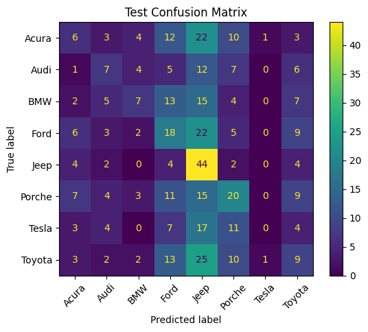

```python
# Predict on test data
y_pred = model.predict(X_test)
# Convert predictions and true labels from one-hot to label indices
y_pred_classes = np.argmax(y_pred, axis=1)
y_true_classes = np.argmax(y_test, axis=1)
y_true = np.argmax(y_test, axis=1)
# Get class labels from the encoder
class_labels = label_encoder.classes_

# Generate classification report
class_report = classification_report(y_true, y_pred_classes, target_names=class_labels)
print("Classification Report Test:\n", class_report)

# Create confusion matrix
cm = confusion_matrix(y_true_classes, y_pred_classes)


# Display confusion matrix
disp = ConfusionMatrixDisplay(confusion_matrix=cm, display_labels=class_labels)
disp.plot(cmap='viridis', xticks_rotation=45)

plt.title('Test Confusion Matrix')
plt.show()
```

```python
#Evaluate on unseen data
test_loss, test_accuracy = model.evaluate(X_test, y_test, verbose=0)
print(f"Test Loss: {test_loss:.4f}")
print(f"Test Accuracy: {test_accuracy:.4f}")
```

```
Test Loss: 1.9536
Test Accuracy: 0.2408
```

# Transfer Learning CNN Pre-trained

```python
import tensorflow as tf
from tensorflow.keras.applications import InceptionResNetV2
from tensorflow.keras.models import Model
from tensorflow.keras.layers import Dense, GlobalAveragePooling2D, Dropout
from tensorflow.keras.optimizers import Adam
from sklearn.model_selection import train_test_split
from tensorflow.keras.utils import to_categorical
from sklearn.preprocessing import LabelEncoder

import pandas as pd
import numpy as np
import os
from sklearn.model_selection import train_test_split

from PIL import Image
#Utilize tensorflow for initial model exploration
import tensorflow as tf
import tensorflow_datasets as tfds

import keras
from keras import models, layers
#helps for image processing
import cv2


import matplotlib.pyplot as plt
```

```python
# Load the Drive helper and mount
from google.colab import drive

# This will prompt for authorization.
drive.mount('/content/drive')
```

```python
brand = ['Acura', 'Ford', 'Jeep', 'Porche', 'BMW', 'Toyota', 'Tesla', 'Audi']
num_images_scraped = [1000, 1000, 1000, 956, 810, 1000, 743, 642 ]

X = []
y = []
#Need minimum size of file to sort out bad ones taken in by the scrape
min_size = 4000
brand_ct = []
j=0

for brand_name in brand:
    bra = brand_name
    print(brand_name)
    brand_counter = 0
    for i in range(1,num_images_scraped[j]):
        #img_src = f'drive/MyDrive/Machine_Learning/{bra}_Images/{i}.jpg'
        img_src = f'drive/MyDrive/UChicago/{bra}_Images/{i}.jpg'
        file_size = os.path.getsize(img_src)
        if min_size <= file_size:
          src = cv2.imread(img_src, cv2.IMREAD_COLOR)
          #dst = cv2.cvtColor(src, cv2.COLOR_BGR2GRAY)
          X.append(cv2.resize(src, dsize=(299, 299), interpolation=cv2.INTER_AREA))
          y.append(bra)
          brand_counter = brand_counter + 1
    brand_ct.append(brand_counter)
    j=j+1
```

```
Acura
Ford
Jeep
Porche
BMW
Toyota
Tesla
Audi
```

[figure not shown]

```python
# Print sample images
fig, axes = plt.subplots(1,10,figsize=(25,10))
for i in range(0,10):
    axes[i].imshow(X[i])
```

```python
# Initialize an empty list for resized images
X_resized_list = []

for img in X:
    # Ensure the image has 3 channels (convert grayscale to RGB if needed)
    if len(img.shape) == 2:  # Grayscale image
        img = tf.image.grayscale_to_rgb(tf.expand_dims(img, axis=-1))
    elif img.shape[-1] != 3:
        raise ValueError("Image does not have 3 channels (RGB).")

    # Resize the image to 299x299
    resized_img = tf.image.resize(img, (299, 299)).numpy()
    X_resized_list.append(resized_img)
```

```python
# Convert list to a numpy array
X_resized = np.array(X_resized_list)

# Normalize images to the range [0, 1]
X_resized = X_resized / 255.0

print(f"Shape of X_resized: {X_resized.shape}")
```

```
Shape of X_resized: (5118, 299, 299, 3)
```

```python
# Convert labels to one-hot encoding
# Encode string labels into integers
label_encoder = LabelEncoder()
y_encoded = label_encoder.fit_transform(y)

# Convert integer labels to one-hot encoding
num_classes = len(np.unique(y_encoded))
y_one_hot = to_categorical(y_encoded, num_classes)


# Split data into training and validation sets
#X_train, X_val, y_train, y_val = train_test_split(X_resized, y_one_hot, test_size=0.2, random_state=42)

# Split data into training and validation sets
X_train, X_val1, y_train, y_val1 = train_test_split(X_resized, y_one_hot, test_size=0.3, random_state=42)
X_val, X_test, y_val, y_test = train_test_split(X_val1, y_val1, test_size=0.3, random_state=42)

# Load InceptionResNetV2 pre-trained model
base_model = InceptionResNetV2(weights='imagenet', include_top=False, input_shape=(299, 299, 3))

# Freeze the base model layers
base_model.trainable = False

# Add custom classification layers
x = base_model.output
x = GlobalAveragePooling2D()(x)
x = Dense(1024, activation='relu')(x)
x = Dropout(0.7)(x)  # Dropout for regularization
predictions = Dense(num_classes, activation='softmax')(x)

# Combine base model and custom layers into one model
model = Model(inputs=base_model.input, outputs=predictions)

# Compile the model
model.compile(optimizer=Adam(learning_rate=0.00008),
              loss='categorical_crossentropy',
              metrics=['accuracy'])

# Train the model
history = model.fit(
    X_train, y_train,
    validation_data=(X_val, y_val),
    batch_size=8,
    epochs=15
)

# Fine-tuning (unfreeze the base model for further training)
base_model.trainable = True
fine_tune_lr = 1e-5
model.compile(optimizer=Adam(learning_rate=fine_tune_lr),
              loss='categorical_crossentropy',
              metrics=['accuracy'])

# Retrain the model
history_fine = model.fit(
    X_train, y_train,
    validation_data=(X_val, y_val),
    batch_size=8,
    epochs=15  # Additional fine-tuning epochs
)

# Save the trained model
model.save('car_brand_classifier_10epochs.h5')

print("Model training complete and saved as 'car_brand_classifier.h5'")
```

```
448/448 ━━━━━━━━━━━━━━━━━━━━ 91s 153ms/step - accuracy: 0.2639 - loss: 1.9836 - val_accuracy: 0.3805 - val_loss: 1.6142
448/448 ━━━━━━━━━━━━━━━━━━━━ 47s 105ms/step - accuracy: 0.3802 - loss: 1.6767 - val_accuracy: 0.4167 - val_loss: 1.5447
448/448 ━━━━━━━━━━━━━━━━━━━━ 47s 106ms/step - accuracy: 0.4010 - loss: 1.5980 - val_accuracy: 0.4130 - val_loss: 1.5427
448/448 ━━━━━━━━━━━━━━━━━━━━ 47s 106ms/step - accuracy: 0.4396 - loss: 1.5240 - val_accuracy: 0.4167 - val_loss: 1.5067
448/448 ━━━━━━━━━━━━━━━━━━━━ 48s 106ms/step - accuracy: 0.4519 - loss: 1.4699 - val_accuracy: 0.4447 - val_loss: 1.4823
448/448 ━━━━━━━━━━━━━━━━━━━━ 48s 107ms/step - accuracy: 0.4638 - loss: 1.4362 - val_accuracy: 0.4474 - val_loss: 1.4581
448/448 ━━━━━━━━━━━━━━━━━━━━ 49s 109ms/step - accuracy: 0.4743 - loss: 1.4124 - val_accuracy: 0.4670 - val_loss: 1.4412
448/448 ━━━━━━━━━━━━━━━━━━━━ 48s 108ms/step - accuracy: 0.5063 - loss: 1.3567 - val_accuracy: 0.4716 - val_loss: 1.4408
448/448 ━━━━━━━━━━━━━━━━━━━━ 48s 108ms/step - accuracy: 0.4832 - loss: 1.3826 - val_accuracy: 0.4698 - val_loss: 1.4240
448/448 ━━━━━━━━━━━━━━━━━━━━ 48s 108ms/step - accuracy: 0.5138 - loss: 1.3502 - val_accuracy: 0.4763 - val_loss: 1.4132
448/448 ━━━━━━━━━━━━━━━━━━━━ 48s 108ms/step - accuracy: 0.5149 - loss: 1.3065 - val_accuracy: 0.4912 - val_loss: 1.3897
448/448 ━━━━━━━━━━━━━━━━━━━━ 48s 108ms/step - accuracy: 0.5307 - loss: 1.2896 - val_accuracy: 0.4800 - val_loss: 1.4124
448/448 ━━━━━━━━━━━━━━━━━━━━ 48s 108ms/step - accuracy: 0.5365 - loss: 1.2754 - val_accuracy: 0.4986 - val_loss: 1.3860
448/448 ━━━━━━━━━━━━━━━━━━━━ 48s 108ms/step - accuracy: 0.5396 - loss: 1.2668 - val_accuracy: 0.4921 - val_loss: 1.3889
448/448 ━━━━━━━━━━━━━━━━━━━━ 48s 108ms/step - accuracy: 0.5525 - loss: 1.2421 - val_accuracy: 0.4995 - val_loss: 1.3834
448/448 ━━━━━━━━━━━━━━━━━━━━ 358s 483ms/step - accuracy: 0.4133 - loss: 1.5774 - val_accuracy: 0.5767 - val_loss: 1.2088
448/448 ━━━━━━━━━━━━━━━━━━━━ 138s 309ms/step - accuracy: 0.6325 - loss: 1.0790 - val_accuracy: 0.6381 - val_loss: 1.0305
448/448 ━━━━━━━━━━━━━━━━━━━━ 142s 317ms/step - accuracy: 0.7522 - loss: 0.7386 - val_accuracy: 0.6679 - val_loss: 0.9463
448/448 ━━━━━━━━━━━━━━━━━━━━ 142s 317ms/step - accuracy: 0.8433 - loss: 0.5160 - val_accuracy: 0.6967 - val_loss: 0.9073
448/448 ━━━━━━━━━━━━━━━━━━━━ 142s 316ms/step - accuracy: 0.9074 - loss: 0.2968 - val_accuracy: 0.7060 - val_loss: 0.9293
448/448 ━━━━━━━━━━━━━━━━━━━━ 142s 317ms/step - accuracy: 0.9426 - loss: 0.2084 - val_accuracy: 0.7219 - val_loss: 0.9452
448/448 ━━━━━━━━━━━━━━━━━━━━ 141s 316ms/step - accuracy: 0.9648 - loss: 0.1279 - val_accuracy: 0.7228 - val_loss: 1.0188
448/448 ━━━━━━━━━━━━━━━━━━━━ 141s 315ms/step - accuracy: 0.9776 - loss: 0.0888 - val_accuracy: 0.7163 - val_loss: 1.1232
448/448 ━━━━━━━━━━━━━━━━━━━━ 141s 315ms/step - accuracy: 0.9792 - loss: 0.0811 - val_accuracy: 0.7135 - val_loss: 1.1330
448/448 ━━━━━━━━━━━━━━━━━━━━ 141s 316ms/step - accuracy: 0.9847 - loss: 0.0659 - val_accuracy: 0.7312 - val_loss: 1.1263
448/448 ━━━━━━━━━━━━━━━━━━━━ 142s 318ms/step - accuracy: 0.9882 - loss: 0.0495 - val_accuracy: 0.7358 - val_loss: 1.1517
448/448 ━━━━━━━━━━━━━━━━━━━━ 142s 317ms/step - accuracy: 0.9886 - loss: 0.0477 - val_accuracy: 0.7302 - val_loss: 1.2137
448/448 ━━━━━━━━━━━━━━━━━━━━ 142s 316ms/step - accuracy: 0.9871 - loss: 0.0437 - val_accuracy: 0.7395 - val_loss: 1.2018
448/448 ━━━━━━━━━━━━━━━━━━━━ 141s 316ms/step - accuracy: 0.9862 - loss: 0.0437 - val_accuracy: 0.7293 - val_loss: 1.2478
448/448 ━━━━━━━━━━━━━━━━━━━━ 141s 315ms/step - accuracy: 0.9942 - loss: 0.0231 - val_accuracy: 0.7460 - val_loss: 1.2670
```

```
WARNING:absl:You are saving your model as an HDF5 file via `model.save()` or `keras.saving.save_model(model)`. This file format is considered legacy. We recommend using instead the native Keras format, e.g. `model.save('my_model.keras')` or `keras.saving.save_model(model, 'my_model.keras')`.
```

```
Model training complete and saved as 'car_brand_classifier.h5'
```

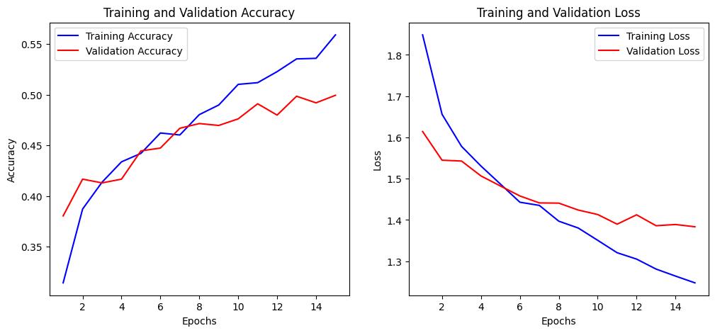

```python
epochs = range(1, len(history.history['accuracy']) + 1)
plt.figure(figsize=(12, 5))

# Accuracy plot
plt.subplot(1, 2, 1)
plt.plot(epochs, history.history['accuracy'], 'b', label='Training Accuracy')
plt.plot(epochs, history.history['val_accuracy'], 'r', label='Validation Accuracy')
plt.title('Training and Validation Accuracy')
plt.xlabel('Epochs')
plt.ylabel('Accuracy')
plt.legend()

# Loss plot
plt.subplot(1, 2, 2)
plt.plot(epochs, history.history['loss'], 'b', label='Training Loss')
plt.plot(epochs, history.history['val_loss'], 'r', label='Validation Loss')
plt.title('Training and Validation Loss')
plt.xlabel('Epochs')
plt.ylabel('Loss')
plt.legend()

plt.show()
```

Overfitting was greatly improed with dropout layers added in. In addition I further tuned learning rate and number of epochs to 15.

```python
val_loss, val_accuracy = model.evaluate(X_val, y_val, verbose=0)
print(f"Val Loss: {val_loss:.4f}")
print(f"Val Accuracy: {val_accuracy:.4f}")
```

```
Val Loss: 1.2670
Val Accuracy: 0.7460
```

```python
test_loss, test_accuracy = model.evaluate(X_test, y_test, verbose=0)
print(f"Test Loss: {test_loss:.4f}")
print(f"Test Accuracy: {test_accuracy:.4f}")
```

```
Test Loss: 1.1660
Test Accuracy: 0.7462
```

```
34/34 ━━━━━━━━━━━━━━━━━━━━ 26s 505ms/step
Classification Report Validation:
               precision    recall  f1-score   support

       Acura       0.75      0.79      0.77       160
        Audi       0.67      0.74      0.70        88
         BMW       0.88      0.73      0.80       123
        Ford       0.74      0.68      0.71       156
        Jeep       0.94      0.90      0.92       138
      Porche       0.69      0.81      0.74       151
       Tesla       0.72      0.65      0.68       110
      Toyota       0.63      0.65      0.64       149

    accuracy                           0.75      1075
   macro avg       0.75      0.74      0.75      1075
weighted avg       0.75      0.75      0.75      1075
```

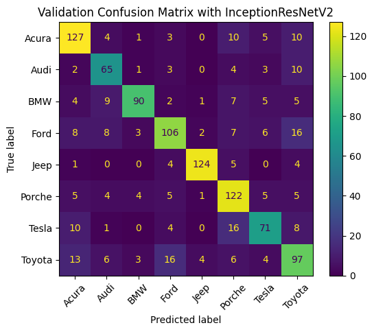

```python
# Predict on Validation data
y_pred = model.predict(X_val)
# Convert predictions and true labels from one-hot to label indices
y_pred_classes = np.argmax(y_pred, axis=1)
y_true_classes = np.argmax(y_val, axis=1)
y_true = np.argmax(y_val, axis=1)
# Get class labels from the encoder
class_labels = label_encoder.classes_

# Generate classification report
class_report = classification_report(y_true, y_pred_classes, target_names=class_labels)
print("Classification Report Validation:\n", class_report)

# Create confusion matrix
cm = confusion_matrix(y_true_classes, y_pred_classes)


# Display confusion matrix
disp = ConfusionMatrixDisplay(confusion_matrix=cm, display_labels=class_labels)
disp.plot(cmap='viridis', xticks_rotation=45)

plt.title('Validation Confusion Matrix with InceptionResNetV2')
plt.show()
```

```
15/15 ━━━━━━━━━━━━━━━━━━━━ 7s 495ms/step
Classification Report Test:
               precision    recall  f1-score   support

       Acura       0.76      0.77      0.76        65
        Audi       0.69      0.71      0.70        51
         BMW       0.81      0.75      0.78        59
        Ford       0.70      0.61      0.65        51
        Jeep       0.91      0.91      0.91        67
      Porche       0.74      0.76      0.75        55
       Tesla       0.65      0.70      0.67        46
      Toyota       0.67      0.72      0.69        67

    accuracy                           0.75       461
   macro avg       0.74      0.74      0.74       461
weighted avg       0.75      0.75      0.75       461
```

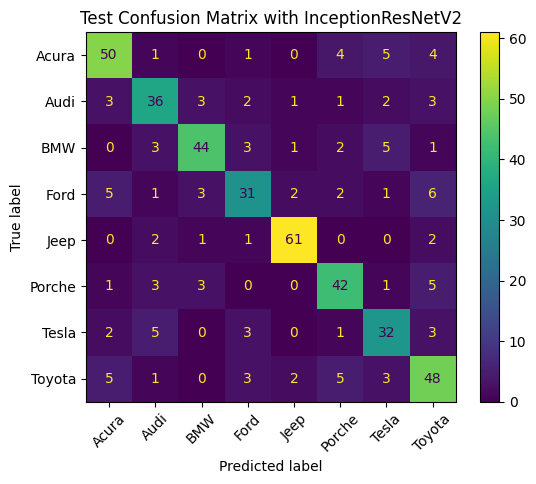

```python
# Predict on test data
y_pred = model.predict(X_test)
# Convert predictions and true labels from one-hot to label indices
y_pred_classes = np.argmax(y_pred, axis=1)
y_true_classes = np.argmax(y_test, axis=1)
y_true = np.argmax(y_test, axis=1)
# Get class labels from the encoder
class_labels = label_encoder.classes_

# Generate classification report
class_report = classification_report(y_true, y_pred_classes, target_names=class_labels)
print("Classification Report Test:\n", class_report)

# Create confusion matrix
cm = confusion_matrix(y_true_classes, y_pred_classes)


# Display confusion matrix
disp = ConfusionMatrixDisplay(confusion_matrix=cm, display_labels=class_labels)
disp.plot(cmap='viridis', xticks_rotation=45)

plt.title('Test Confusion Matrix with InceptionResNetV2')
plt.show()
```

# VIT model - no transfer learning

```python
! pip install linformer
```

```
Downloading linformer-0.2.3-py3-none-any.whl (6.2 kB)
```

```python
! pip install vit_pytorch
```

```
     ━━━━━━━━━━━━━━━━━━━━━━━━━━━━━━━━━━━━━━━━ 0.0/68.8 kB ? eta -:--:--
     ━━━━━━━━━━━━━━━━━━━━━━━━━━━━━━━━━━━━━━━━ 68.8/68.8 kB 4.6 MB/s eta 0:00:00
Downloading vit_pytorch-1.8.9-py3-none-any.whl (135 kB)
   ━━━━━━━━━━━━━━━━━━━━━━━━━━━━━━━━━━━━━━━━ 135.9/135.9 kB 8.5 MB/s eta 0:00:00
```

```python
from __future__ import print_function

import glob
from itertools import chain
import os
import random
import zipfile

import tensorflow as tf
from sklearn.model_selection import train_test_split
from sklearn.preprocessing import LabelEncoder

import matplotlib.pyplot as plt
import numpy as np
import pandas as pd

import torch
import torch.nn as nn
import torch.nn.functional as F
import torch.optim as optim
from linformer import Linformer
from PIL import Image
from sklearn.model_selection import train_test_split
from torch.optim.lr_scheduler import StepLR
from torch.utils.data import DataLoader, Dataset
from torchvision import datasets, transforms
from tqdm.notebook import tqdm


from transformers import ViTForImageClassification, ViTConfig
from vit_pytorch.efficient import ViT

import cv2

import torch
import torch.nn as nn
from torch.utils.data import DataLoader, Dataset
from torchvision import transforms
from transformers import ViTForImageClassification, ViTConfig
from sklearn.preprocessing import LabelEncoder
import numpy as np
```

```python
# Load the Drive helper and mount
from google.colab import drive

# This will prompt for authorization.
drive.mount('/content/drive')
```

```python
# Training settings
batch_size = 64
epochs = 5
lr = 3e-5
gamma = 0.7
seed = 42
```

```python
def seed_everything(seed):
    random.seed(seed)
    os.environ['PYTHONHASHSEED'] = str(seed)
    np.random.seed(seed)
    torch.manual_seed(seed)
    torch.cuda.manual_seed(seed)
    torch.cuda.manual_seed_all(seed)
    torch.backends.cudnn.deterministic = True

seed_everything(seed)

device = 'cuda'
```

```python
brand = ['Acura', 'Ford', 'Jeep', 'Porche', 'BMW', 'Toyota', 'Tesla', 'Audi']
num_images_scraped = [1000, 1000, 1000, 956, 810, 1000, 743, 642 ]

X = []
y = []
#Need minimum size of file to sort out bad ones taken in by the scrape
min_size = 4000
brand_ct = []
j=0

for brand_name in brand:
    bra = brand_name
    print(brand_name)
    brand_counter = 0
    for i in range(1,num_images_scraped[j]):
        #img_src = f'drive/MyDrive/Machine_Learning/{bra}_Images/{i}.jpg'
        img_src = f'drive/MyDrive/UChicago/{bra}_Images/{i}.jpg'
        file_size = os.path.getsize(img_src)
        if min_size <= file_size:
          src = cv2.imread(img_src, cv2.IMREAD_COLOR)
          #dst = cv2.cvtColor(src, cv2.COLOR_BGR2GRAY)
          X.append(cv2.resize(src, dsize=(299, 299), interpolation=cv2.INTER_AREA))
          y.append(bra)
          brand_counter = brand_counter + 1
    brand_ct.append(brand_counter)
    j=j+1
```

```
Acura
Ford
Jeep
Porche
BMW
Toyota
Tesla
Audi
```

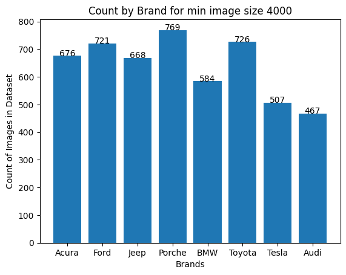

```python
#plot number in dataset by brand
def addlabels(x,y):
    for i in range(len(x)):
        plt.text(i, y[i], y[i], ha = 'center')

plt.bar(brand, brand_ct)

plt.xlabel('Brands')
addlabels(brand, brand_ct)
plt.ylabel('Count of Images in Dataset')
plt.title(f'Count by Brand for min image size {min_size}')

plt.show()
```

```python
# Initialize an empty list for resized images
X_resized_list = []

for img in X:
    # Ensure the image has 3 channels (convert grayscale to RGB if needed)
    if len(img.shape) == 2:  # Grayscale image
        img = tf.image.grayscale_to_rgb(tf.expand_dims(img, axis=-1))
    elif img.shape[-1] != 3:
        raise ValueError("Image does not have 3 channels (RGB).")

    # Resize the image to 299x299
    resized_img = tf.image.resize(img, (299, 299)).numpy()
    X_resized_list.append(resized_img)
```

```python
# Convert list to a numpy array
X_resized = np.array(X_resized_list)

# Normalize images to the range [0, 1]
X_resized = X_resized / 255.0

print(f"Shape of X_resized: {X_resized.shape}")
```

```
Shape of X_resized: (5118, 299, 299, 3)
```

```python
# Split data into training and validation sets, leave out some for test
X_train, X_val1, y_train, y_val1 = train_test_split(X_resized, y, test_size=0.3, random_state=42)
X_val, X_test, y_val, y_test = train_test_split(X_val1, y_val1, test_size=0.3, random_state=42)
```

```python
# Create a Custom Dataset Class
class CarBrandDataset(Dataset):
    def __init__(self, images, labels, transform=None):
        self.images = images
        self.labels = labels
        self.transform = transform

    def __len__(self):
        return len(self.images)

    def __getitem__(self, idx):
        image = self.images[idx]
        label = self.labels[idx]
        if self.transform:
            image = self.transform(image)
        return image, label

# Preprocessing
transform = transforms.Compose([
    transforms.ToPILImage(),
    transforms.Resize((224, 224)),
    transforms.ToTensor(),
    transforms.Normalize(mean=[0.5, 0.5, 0.5], std=[0.5, 0.5, 0.5]),
])
```

```python
# Encode labels
label_encoder = LabelEncoder()
y_train_encoded = label_encoder.fit_transform(y_train)
y_val_encoded = label_encoder.transform(y_val)
y_test_encoded = label_encoder.transform(y_test)

# Create datasets and dataloaders
train_dataset = CarBrandDataset(X_train, y_train_encoded, transform=transform)
val_dataset = CarBrandDataset(X_val, y_val_encoded, transform=transform)
test_dataset = CarBrandDataset(X_test, y_test_encoded, transform=transform)

train_loader = DataLoader(train_dataset, batch_size=32, shuffle=True)
val_loader = DataLoader(val_dataset, batch_size=32, shuffle=False)
test_loader = DataLoader(test_dataset, batch_size=32, shuffle=False)

# Define the Model
num_classes = len(label_encoder.classes_)
model_config = ViTConfig(image_size=224, num_labels=num_classes)
model = ViTForImageClassification(model_config)

# Training Configuration
device = torch.device("cuda" if torch.cuda.is_available() else "cpu")
model.to(device)

criterion = nn.CrossEntropyLoss()
optimizer = torch.optim.Adam(model.parameters(), lr=1e-4)
```

```python
# Training Loop
def train_model(model, train_loader, val_loader, epochs=10):
    for epoch in range(epochs):
        model.train()
        train_loss = 0.0
        for images, labels in train_loader:
            images, labels = images.to(device), labels.to(device)
            optimizer.zero_grad()
            outputs = model(images).logits
            loss = criterion(outputs, labels)
            loss.backward()
            optimizer.step()
            train_loss += loss.item()

        model.eval()
        val_loss = 0.0
        correct = 0
        total = 0
        with torch.no_grad():
            for images, labels in val_loader:
                images, labels = images.to(device), labels.to(device)
                outputs = model(images).logits
                loss = criterion(outputs, labels)
                val_loss += loss.item()
                _, predicted = torch.max(outputs, 1)
                correct += (predicted == labels).sum().item()
                total += labels.size(0)

        val_accuracy = correct / total
        print(f"Epoch {epoch+1}/{epochs}, Train Loss: {train_loss/len(train_loader):.4f}, "
              f"Val Loss: {val_loss/len(val_loader):.4f}, Val Accuracy: {val_accuracy:.4f}")


# Train the model
train_model(model, train_loader, val_loader, epochs=10)
```

```python
# Evaluate on Test Data
def evaluate_model(model, test_loader):
    model.eval()
    correct = 0
    total = 0
    with torch.no_grad():
        for images, labels in test_loader:
            images, labels = images.to(device), labels.to(device)
            outputs = model(images).logits
            _, predicted = torch.max(outputs, 1)
            correct += (predicted == labels).sum().item()
            total += labels.size(0)
    accuracy = correct / total
    print(f"Test Accuracy: {accuracy:.4f}")

evaluate_model(model, test_loader)
```

```
Test Accuracy: 0.1605
```

Very poor performance, although this is expected with a transformer model on a small dataset. Due to limits on computational resources, I decided not to tune this further, and spend resources on a transfer learning model which is more likely to be sucessful.

# VIT with transfer Learning

```python
import torch
import torch.nn as nn
from torch.utils.data import DataLoader, Dataset
from torchvision import transforms
from transformers import ViTForImageClassification, ViTFeatureExtractor
from sklearn.preprocessing import LabelEncoder
import matplotlib.pyplot as plt
```

```python
# Define custom dataset
class CarBrandDataset(Dataset):
    def __init__(self, images, labels, transform=None):
        self.images = images
        self.labels = labels
        self.transform = transform

    def __len__(self):
        return len(self.images)

    def __getitem__(self, idx):
        image = self.images[idx]
        label = self.labels[idx]
        if self.transform:
            image = self.transform(image)
        return image, label

# Add preprocessing transforms
feature_extractor = ViTFeatureExtractor.from_pretrained('google/vit-base-patch16-224-in21k')
transform = transforms.Compose([
    transforms.ToPILImage(),
    transforms.Resize((224, 224)),
    transforms.ToTensor(),
    transforms.Normalize(mean=feature_extractor.image_mean, std=feature_extractor.image_std),
])

# Encode labels
label_encoder = LabelEncoder()
y_train_encoded = label_encoder.fit_transform(y_train)
y_val_encoded = label_encoder.transform(y_val)
y_test_encoded = label_encoder.transform(y_test)

# Create datasets and dataloaders
train_dataset = CarBrandDataset(X_train, y_train_encoded, transform=transform)
val_dataset = CarBrandDataset(X_val, y_val_encoded, transform=transform)
test_dataset = CarBrandDataset(X_test, y_test_encoded, transform=transform)

train_loader = DataLoader(train_dataset, batch_size=32, shuffle=True)
val_loader = DataLoader(val_dataset, batch_size=32, shuffle=False)
test_loader = DataLoader(test_dataset, batch_size=32, shuffle=False)

# Load pre-trained ViT model
model = ViTForImageClassification.from_pretrained(
    'google/vit-base-patch16-224-in21k',
    num_labels=len(label_encoder.classes_)
)
model.to(device)

# Loss and optimizer
criterion = nn.CrossEntropyLoss()
optimizer = torch.optim.AdamW(model.parameters(), lr=1e-4)

# GFLOPs calculation
#def compute_gflops(model, train_loader):
 #   example_images, _ = next(iter(train_loader))
  #  example_images = example_images.to(device)
   # with torch.profiler.profile(activities=[torch.profiler.ProfilerActivity.CPU, torch.profiler.ProfilerActivity.CUDA]) as prof:
    #    model(example_images).logits
   # flops = sum([e.flops for e in prof.key_averages() if e.flops is not None])
   # gflops = flops / 1e9  # Convert FLOPs to GFLOPs
   # return gflops

# Training loop
train_accuracies, val_accuracies, gflops_per_epoch = [], [], []

def train_model(model, train_loader, val_loader, epochs=10):
    for epoch in range(epochs):
        model.train()
        correct_train, total_train = 0, 0
        for images, labels in train_loader:
            images, labels = images.to(device), labels.to(device)
            optimizer.zero_grad()
            outputs = model(images).logits
            loss = criterion(outputs, labels)
            loss.backward()
            optimizer.step()

            _, predicted = torch.max(outputs, 1)
            correct_train += (predicted == labels).sum().item()
            total_train += labels.size(0)

        train_accuracy = correct_train / total_train
        train_accuracies.append(train_accuracy)


        # Validation
        model.eval()
        correct_val, total_val = 0, 0
        with torch.no_grad():
            for images, labels in val_loader:
                images, labels = images.to(device), labels.to(device)
                outputs = model(images).logits
                _, predicted = torch.max(outputs, 1)
                correct_val += (predicted == labels).sum().item()
                total_val += labels.size(0)

        val_accuracy = correct_val / total_val
        val_accuracies.append(val_accuracy)

        # Compute total GFLOPs
     #   gflops = compute_gflops(model, train_loader)
      #  gflops_per_epoch.append(gflops)

        print(f"Epoch {epoch+1}/{epochs}, Train Accuracy: {train_accuracy:.4f}, "
              f"Val Accuracy: {val_accuracy:.4f}, Total GFLOPs: {gflops:.2f}")

# Train the model
train_model(model, train_loader, val_loader, epochs=10)


# Print total GFLOPs per epoch
for epoch, gflops in enumerate(gflops_per_epoch, 1):
    print(f"Epoch {epoch}: Total GFLOPs: {gflops:.5f}")
```

```python
import torch
from torch.profiler import profile, ProfilerActivity

# Function to compute total GFLOPs
def compute_total_gflops(model, input_size=(32, 3, 224, 224)):
    """
    Compute total GFLOPs for a given model and input size.

    Args:
        model: The PyTorch model to evaluate.
        input_size: The shape of a batch of inputs (batch_size, channels, height, width).

    Returns:
        Total GFLOPs.
    """
    dummy_input = torch.randn(input_size).to(device)
    model.eval()

    with profile(activities=[ProfilerActivity.CPU, ProfilerActivity.CUDA], with_flops=True) as prof:
        model(dummy_input)

    # Sum up all FLOPs recorded
    total_flops = sum([entry.flops for entry in prof.key_averages() if entry.flops is not None])
    total_gflops = total_flops / 1e9  # Convert FLOPs to GFLOPs
    return total_gflops

# Compute GFLOPs for the model
input_batch_size = 32  # Define batch size for FLOP calculation
gflops = compute_total_gflops(model, input_size=(input_batch_size, 3, 224, 224))
print(f"Total GFLOPs for the ViT model: {gflops:.2f}")
```

```
Total GFLOPs for the ViT model: 1078.38
```

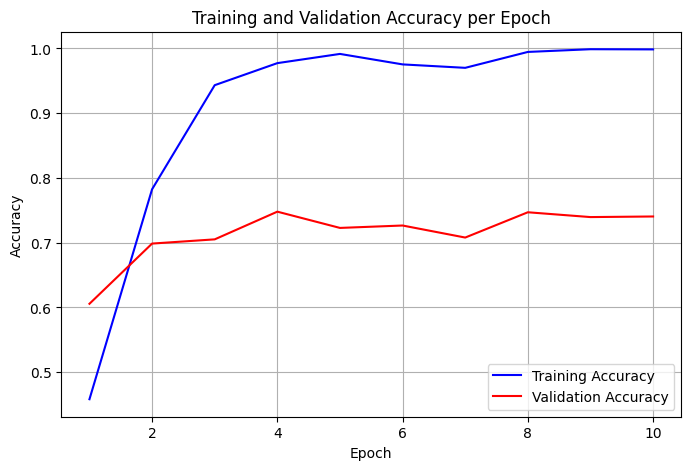

```python
# Plot accuracy
plt.figure(figsize=(8, 5))
plt.plot(range(1, len(train_accuracies) + 1), train_accuracies, 'b', label="Training Accuracy")
plt.plot(range(1, len(val_accuracies) + 1), val_accuracies, 'r', label="Validation Accuracy")
plt.xlabel("Epoch")
plt.ylabel("Accuracy")
plt.title("Training and Validation Accuracy per Epoch")
plt.legend()
plt.grid()
plt.show()
```

```python
# Evaluate on Test Data
def evaluate_model(model, test_loader):
    model.eval()
    correct = 0
    total = 0
    with torch.no_grad():
        for images, labels in test_loader:
            images, labels = images.to(device), labels.to(device)
            outputs = model(images).logits
            _, predicted = torch.max(outputs, 1)
            correct += (predicted == labels).sum().item()
            total += labels.size(0)
    accuracy = correct / total
    print(f"Test Accuracy: {accuracy:.4f}")

evaluate_model(model, test_loader)

# Save the Fine-tuned Model
torch.save(model.state_dict(), "vit_car_brand_classifier.pt")
```

```
Test Accuracy: 0.7614
```

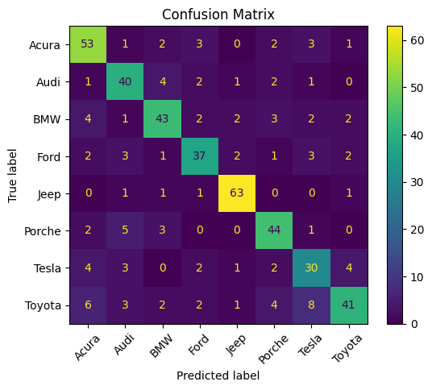

```python
from sklearn.metrics import confusion_matrix, ConfusionMatrixDisplay
import numpy as np

# Evaluate the model on the test set and collect predictions
model.eval()
all_preds, all_labels = [], []

with torch.no_grad():
    for images, labels in DataLoader(test_dataset, batch_size=32, shuffle=False):
        images = images.to(device)
        labels = labels.to(device)
        outputs = model(images).logits
        _, preds = torch.max(outputs, 1)

        all_preds.extend(preds.cpu().numpy())
        all_labels.extend(labels.cpu().numpy())

# Decode predictions and labels
decoded_preds = label_encoder.inverse_transform(all_preds)
decoded_labels = label_encoder.inverse_transform(all_labels)

# Compute the confusion matrix
cm = confusion_matrix(decoded_labels, decoded_preds, labels=label_encoder.classes_)

# Plot the confusion matrix
disp = ConfusionMatrixDisplay(confusion_matrix=cm, display_labels=label_encoder.classes_)
fig, ax = plt.subplots()
disp.plot(ax=ax, cmap='viridis', xticks_rotation=45)
plt.title("Confusion Matrix")
plt.show()
```

## With Fine Tuning

```python
from transformers import ViTForImageClassification, AdamW
from sklearn.metrics import confusion_matrix, ConfusionMatrixDisplay
import matplotlib.pyplot as plt
import torch
import torch.nn as nn
from torch.utils.data import DataLoader
from transformers import ViTFeatureExtractor
from torchvision import transforms
from tqdm import tqdm

# Assume these are defined: train_dataset, val_dataset, test_dataset
# Also assume train_loader, val_loader, test_loader are already created.


# Define custom dataset
class CarBrandDataset(Dataset):
    def __init__(self, images, labels, transform=None):
        self.images = images
        self.labels = labels
        self.transform = transform

    def __len__(self):
        return len(self.images)

    def __getitem__(self, idx):
        image = self.images[idx]
        label = self.labels[idx]
        if self.transform:
            image = self.transform(image)
        return image, label

# Add preprocessing transforms
feature_extractor = ViTFeatureExtractor.from_pretrained('google/vit-base-patch16-224-in21k')
transform = transforms.Compose([
    transforms.ToPILImage(),
    transforms.Resize((224, 224)),
    transforms.ToTensor(),
    transforms.Normalize(mean=feature_extractor.image_mean, std=feature_extractor.image_std),
])

# Encode labels
label_encoder = LabelEncoder()
y_train_encoded = label_encoder.fit_transform(y_train)
y_val_encoded = label_encoder.transform(y_val)
y_test_encoded = label_encoder.transform(y_test)

# Create datasets and dataloaders
train_dataset = CarBrandDataset(X_train, y_train_encoded, transform=transform)
val_dataset = CarBrandDataset(X_val, y_val_encoded, transform=transform)
test_dataset = CarBrandDataset(X_test, y_test_encoded, transform=transform)

train_loader = DataLoader(train_dataset, batch_size=32, shuffle=True)
val_loader = DataLoader(val_dataset, batch_size=32, shuffle=False)
test_loader = DataLoader(test_dataset, batch_size=32, shuffle=False)

# Define the device
device = torch.device("cuda" if torch.cuda.is_available() else "cpu")

# Load the pre-trained ViT model
model = ViTForImageClassification.from_pretrained(
    "google/vit-base-patch16-224-in21k",
    num_labels=len(label_encoder.classes_)
)
model.to(device)

# Define loss and optimizer for initial training
criterion = nn.CrossEntropyLoss()
initial_lr = 5e-5
optimizer = AdamW(model.parameters(), lr=initial_lr)

train_accuracies, val_accuracies, gflops_per_epoch = [], [], []

# Train the model function
def train_model(model, train_loader, val_loader, epochs=5):
    model.train()
    for epoch in range(epochs):
        correct_train, total_train = 0, 0
        total_loss = 0

        for images, labels in tqdm(train_loader, desc=f"Epoch {epoch+1}/{epochs}"):
            images, labels = images.to(device), labels.to(device)

            # Forward pass
            outputs = model(images).logits
            loss = criterion(outputs, labels)

            # Backward pass and optimization
            optimizer.zero_grad()
            loss.backward()
            optimizer.step()

            # Calculate accuracy
            _, predicted = torch.max(outputs, 1)
            correct_train += (predicted == labels).sum().item()
            total_train += labels.size(0)
            total_loss += loss.item()

        train_accuracy = correct_train / total_train
        train_accuracies.append(train_accuracy)
        print(f"Epoch {epoch+1}/{epochs}, Train Loss: {total_loss:.4f}, Train Accuracy: {train_accuracy:.4f}")

        # Validation phase
        model.eval()
        correct_val, total_val = 0, 0
        with torch.no_grad():
            for images, labels in val_loader:
                images, labels = images.to(device), labels.to(device)
                outputs = model(images).logits
                _, predicted = torch.max(outputs, 1)
                correct_val += (predicted == labels).sum().item()
                total_val += labels.size(0)

        val_accuracy = correct_val / total_val
        val_accuracies.append(val_accuracy)
        print(f"Epoch {epoch+1}/{epochs}, Validation Accuracy: {val_accuracy:.4f}")
        model.train()  # Switch back to training mode after evaluation

# Initial training
print("Starting initial training...")
train_model(model, train_loader, val_loader, epochs=5)

# Fine-tuning
# Unfreeze all layers for fine-tuning
for param in model.parameters():
    param.requires_grad = True

# Use a smaller learning rate for fine-tuning
fine_tune_lr = 1e-5
fine_tune_optimizer = AdamW(model.parameters(), lr=fine_tune_lr)

def fine_tune_model(model, train_loader, val_loader, epochs=5):
    model.train()
    for epoch in range(epochs):
        correct_train, total_train = 0, 0
        total_loss = 0

        for images, labels in tqdm(train_loader, desc=f"Fine-tune Epoch {epoch+1}/{epochs}"):
            images, labels = images.to(device), labels.to(device)

            # Forward pass
            outputs = model(images).logits
            loss = criterion(outputs, labels)

            # Backward pass and optimization
            fine_tune_optimizer.zero_grad()
            loss.backward()
            fine_tune_optimizer.step()

            # Calculate accuracy
            _, predicted = torch.max(outputs, 1)
            correct_train += (predicted == labels).sum().item()
            total_train += labels.size(0)
            total_loss += loss.item()

        train_accuracy = correct_train / total_train
        train_accuracies.append(train_accuracy)
        print(f"Fine-tune Epoch {epoch+1}/{epochs}, Train Loss: {total_loss:.4f}, Train Accuracy: {train_accuracy:.4f}")

        # Validation phase
        model.eval()
        correct_val, total_val = 0, 0
        with torch.no_grad():
            for images, labels in val_loader:
                images, labels = images.to(device), labels.to(device)
                outputs = model(images).logits
                _, predicted = torch.max(outputs, 1)
                correct_val += (predicted == labels).sum().item()
                total_val += labels.size(0)

        val_accuracy = correct_val / total_val
        val_accuracies.append(val_accuracy)
        print(f"Fine-tune Epoch {epoch+1}/{epochs}, Validation Accuracy: {val_accuracy:.4f}")
        model.train()  # Switch back to training mode after evaluation

# Perform fine-tuning
print("Starting fine-tuning...")
fine_tune_model(model, train_loader, val_loader, epochs=5)
```

```
Starting initial training...
```

```
Starting fine-tuning...
```

```
Fine-tune Epoch 1/5, Train Loss: 6.5631, Train Accuracy: 0.9994
Fine-tune Epoch 1/5, Validation Accuracy: 0.7414
```

```
Fine-tune Epoch 2/5, Train Loss: 4.9058, Train Accuracy: 0.9997
Fine-tune Epoch 2/5, Validation Accuracy: 0.7386
```

```
Fine-tune Epoch 3/5, Train Loss: 3.8877, Train Accuracy: 1.0000
Fine-tune Epoch 3/5, Validation Accuracy: 0.7405
```

```
Fine-tune Epoch 4/5, Train Loss: 3.2326, Train Accuracy: 1.0000
Fine-tune Epoch 4/5, Validation Accuracy: 0.7386
```

```
Fine-tune Epoch 5/5, Train Loss: 2.7474, Train Accuracy: 1.0000
Fine-tune Epoch 5/5, Validation Accuracy: 0.7386
```

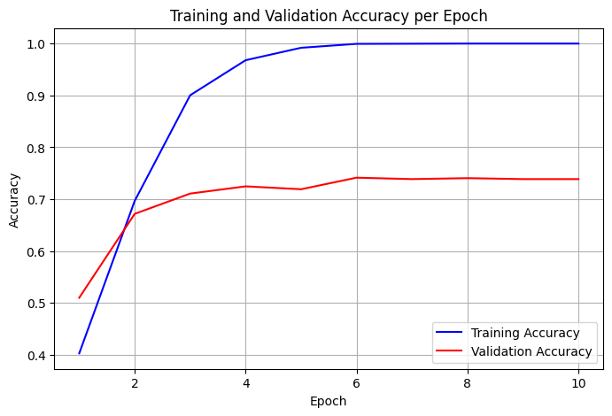

```python
plt.figure(figsize=(8, 5))
plt.plot(range(1, len(train_accuracies) + 1), train_accuracies, 'b', label="Training Accuracy")
plt.plot(range(1, len(val_accuracies) + 1), val_accuracies, 'r', label="Validation Accuracy")
plt.xlabel("Epoch")
plt.ylabel("Accuracy")
plt.title("Training and Validation Accuracy per Epoch")
plt.legend()
plt.grid()
plt.show()
```

```python
# Evaluate on Test Data
#test_loader = DataLoader(test_dataset, batch_size=32, shuffle=False)
def evaluate_model(model, val_loader):
    model.eval()
    correct = 0
    total = 0
    with torch.no_grad():
        for images, labels in test_loader:
            images, labels = images.to(device), labels.to(device)
            outputs = model(images).logits
            _, predicted = torch.max(outputs, 1)
            correct += (predicted == labels).sum().item()
            total += labels.size(0)
    accuracy = correct / total
    print(f"Val Accuracy: {accuracy:.4f}")
evaluate_model(model, val_loader)
```

```
Val Accuracy: 0.7809
```

```python
# Evaluate on Test Data
#test_loader = DataLoader(test_dataset, batch_size=32, shuffle=False)
def evaluate_model(model, test_loader):
    model.eval()
    correct = 0
    total = 0
    with torch.no_grad():
        for images, labels in test_loader:
            images, labels = images.to(device), labels.to(device)
            outputs = model(images).logits
            _, predicted = torch.max(outputs, 1)
            correct += (predicted == labels).sum().item()
            total += labels.size(0)
    accuracy = correct / total
    print(f"Test Accuracy: {accuracy:.4f}")

evaluate_model(model, test_loader)
```

[output not shown]

```
Classification Report Test:
               precision    recall  f1-score   support

       Acura       0.89      0.75      0.82        65
        Audi       0.69      0.78      0.73        51
         BMW       0.83      0.66      0.74        59
        Ford       0.73      0.65      0.69        51
        Jeep       0.91      0.93      0.92        67
      Porche       0.87      0.85      0.86        55
       Tesla       0.69      0.67      0.68        46
      Toyota       0.66      0.88      0.76        67

    accuracy                           0.78       461
   macro avg       0.78      0.77      0.77       461
weighted avg       0.79      0.78      0.78       461
```

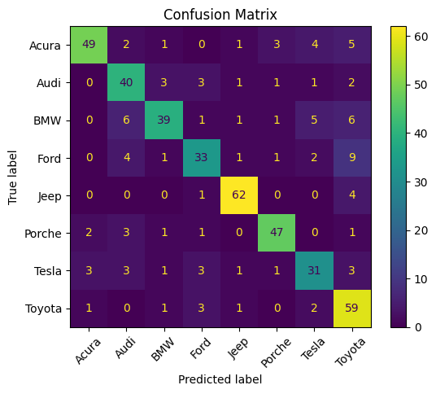

```python
# Test the model and generate a confusion matrix
model.eval()
all_preds, all_labels = [], []

with torch.no_grad():
    for images, labels in test_loader:
        images, labels = images.to(device), labels.to(device)
        outputs = model(images).logits
        _, preds = torch.max(outputs, 1)

        all_preds.extend(preds.cpu().numpy())
        all_labels.extend(labels.cpu().numpy())

# Decode predictions and labels
decoded_preds = label_encoder.inverse_transform(all_preds)
decoded_labels = label_encoder.inverse_transform(all_labels)

# Generate classification report
# Get class labels from the encoder
class_labels = label_encoder.classes_
class_report = classification_report(all_labels, all_preds, target_names=class_labels)
print("Classification Report Test:\n", class_report)

# Confusion matrix
cm = confusion_matrix(decoded_labels, decoded_preds, labels=label_encoder.classes_)
disp = ConfusionMatrixDisplay(confusion_matrix=cm, display_labels=label_encoder.classes_)
fig, ax = plt.subplots()
disp.plot(ax=ax, cmap='viridis', xticks_rotation=45)
plt.title("Confusion Matrix")
plt.show()
```

# Analysis of Results & Model Justification

**Ranked Performance on unseen test images:**

1. ViT with transfer learning: 76% Test Accuracy
2. CNN with transfer learning: 75% Test Accuracy
3. CNN without transfer learning: 24% Test Accuracy
4. ViT without transfer learning: 16% Test Accuracy

For the pretrained ViT model, I used Vit Base Patch16 224 In21k which is a ViT model pre-trained on ImageNet-21K. I ran with 10 epochs, but validation accuracy was not greatly improved after 6 epochs.

**Insights:**

I observed similar training time for each transfer learning model, and almost the same level of accuracy achieved Suggests that ViT models may be a viable alternative to CNNs for the task of car brand classification. Training a ViT model on a larger dataset may be less computationally expensive than training a CNN Models without transfer learning had insurmountable overfitting and low performance issues due to small dataset size.

# Future Direction:

- Gigaflop computation - I computed gigaflops for models made with PyTorch, but the CNN models were made using Keras where I found no package or successful methodology for gigaflop computation. Comparison of gigaflops for each model would help to determine which had the best performance with the fewest computations.
- Explore transfer learning with other pre-trained models.
- Extend to car brands not included in the training dataset. A larger training dataset may help to improve model performance and efficacy.